# Model fit diagnostics

Per veg_fire class — elastic-net tuning, coefficients, calibration, OOF predictions

Author

Iván Barberá

Published

June 17, 2026

```r
library(data.table)
library(tidyverse)
library(scales)
library(knitr)

models_dir <- "../models"                        # notebook runs from collection-01/notebooks/
theme_set(theme_minimal(base_size = 12))
block_lvls <- c("focal", "prev", "pairs", "sameband", "cross_idx", "cross_band")

# Discover every fitted class from its per-class cv_metrics sidecar, ordered by code.
metric_files <- Sys.glob(file.path(models_dir, "class_*_cv_metrics.csv"))
codes <- sort(as.integer(sub(".*class_0*(\\d+)_cv_metrics\\.csv$", "\\1", metric_files)))
stopifnot(length(codes) > 0)
```

This report renders one top-level section per **fitted veg_fire class** (discovered from `models/class_*_cv_metrics.csv`), each with the same subsections: summary, elastic-net tuning, coefficients, calibration, OOF probability distribution, and a by-fire breakdown. The per-class plotting code lives in the child template `_model_fit_diagnostics_child.qmd`. Currently fitted: **3** class(es).

```r
out <- character()
for (CLASS_CODE in codes) {
  tag <- sprintf("class_%02d", CLASS_CODE)
  rd  <- function(suffix) fread(file.path(models_dir, sprintf("%s_%s", tag, suffix)))
  metrics <- rd("cv_metrics.csv")
  tuning  <- rd("tuning.csv")
  coefs   <- rd("coefficients.csv")
  oof     <- rd("oof_predictions.csv")
  cls     <- metrics$veg_fire_name[1]
  out <- c(out, knitr::knit_child("_model_fit_diagnostics_child.qmd",
                                  envir = environment(), quiet = TRUE))
}
cat(out, sep = "\n")
```

# 1 agriculture_pat

veg_fire code **4** · regions PAT · 20,069 obs · 2,506 positives (12.5%) · K = 10 · 42 nonzero terms

## 1.1 Summary

```r
metrics |>
  mutate(across(where(is.numeric), \(x) signif(x, 4))) |>
  pivot_longer(everything(), names_to = "metric", values_to = "value",
               values_transform = as.character) |>
  kable()
```

| metric | value |
| --- | --- |
| veg_fire | 4 |
| veg_fire_name | agriculture_pat |
| regions | PAT |
| n_obs | 20070 |
| n_pos | 2506 |
| K | 10 |
| n_terms | 427 |
| alpha | 0.5 |
| lambda_rule | 1se |
| lambda | 0.01522 |
| lambda_min | 0.004542 |
| lambda_1se | 0.01522 |
| cv_deviance | 0.11 |
| cv_logloss | 0.055 |
| cv_brier | 0.01398 |
| cv_auc | 0.9963 |
| n_nonzero | 42 |

The model is fit with elastic net; `alpha` and `lambda` are tuned by grouped (leave-several-fires-out) K-fold CV. `lambda` reported is the one selected by `lambda_rule`. `n_nonzero` is the count of nonzero coefficients (excl. intercept).

## 1.2 Elastic-net tuning

CV binomial deviance along the lambda path, one curve per `alpha`. Vertical lines mark `lambda.min` (dashed) and `lambda.1se` (dotted) of the selected alpha; the chosen model sits at the rule in `metrics$lambda_rule`.

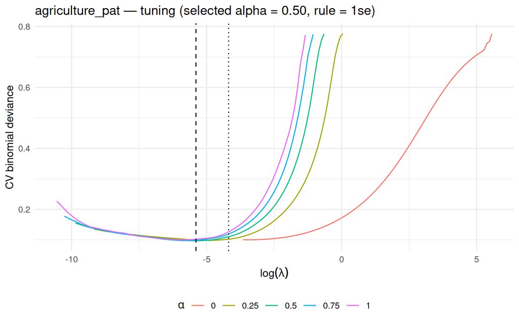

```r
sel_alpha <- metrics$alpha[1]
ggplot(tuning, aes(log(lambda), cvm, color = factor(alpha))) +
  geom_line() +
  geom_vline(xintercept = log(metrics$lambda_min[1]), linetype = "dashed") +
  geom_vline(xintercept = log(metrics$lambda_1se[1]), linetype = "dotted") +
  labs(x = expression(log(lambda)), y = "CV binomial deviance",
       color = expression(alpha),
       title = sprintf("%s — tuning (selected alpha = %.2f, rule = %s)",
                       cls, sel_alpha, metrics$lambda_rule[1])) +
  theme(legend.position = "bottom")
```

## 1.3 Coefficients

Nonzero coefficients by block (the GEE predictor blocks) and the strongest terms.

Coefficients are on the **original feature scale** — `glmnet` standardizes each predictor internally (`standardize = TRUE`) but back-transforms the returned coefficients to the raw scale. A clean cross-term comparison would need them on the *standardized* scale (multiply each $\beta_j$ by $\mathrm{sd}(x_j)$, i.e. the effect of a 1-SD change), but the per-feature SDs are not exported by `02-model_fitting.R` and recovering them would mean rebuilding the full 427-column design matrix from the region tables here. That is deliberately left out — read the magnitudes below as raw-scale, so a large coefficient on a small-variance term need not mean a large effect.

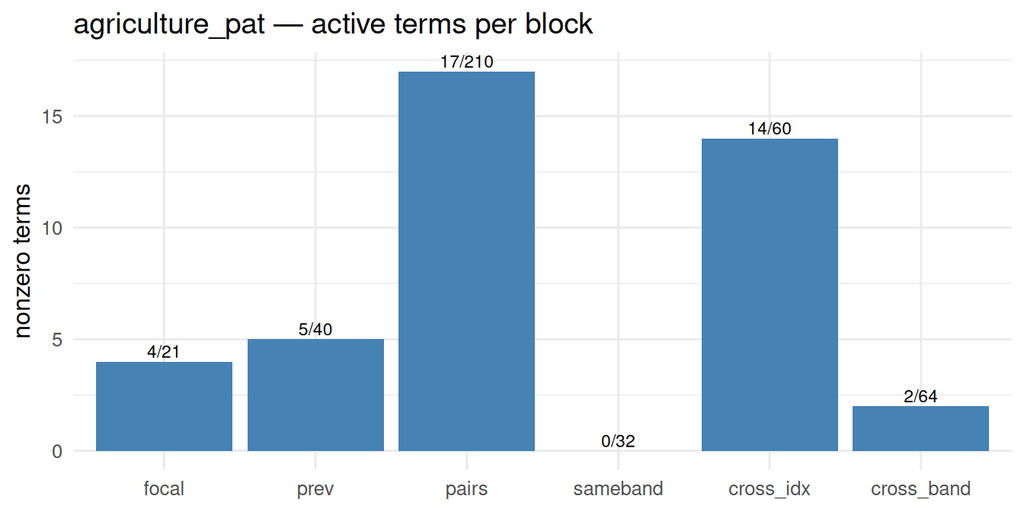

```r
coefs |>
  filter(block != "(intercept)") |>
  group_by(block) |>
  summarise(n_terms = n(), n_nonzero = sum(coefficient != 0), .groups = "drop") |>
  mutate(block = factor(block, block_lvls)) |>
  ggplot(aes(block, n_nonzero)) +
  geom_col(fill = "steelblue") +
  geom_text(aes(label = sprintf("%d/%d", n_nonzero, n_terms)), vjust = -0.3, size = 3) +
  labs(x = NULL, y = "nonzero terms", title = sprintf("%s — active terms per block", cls))
```

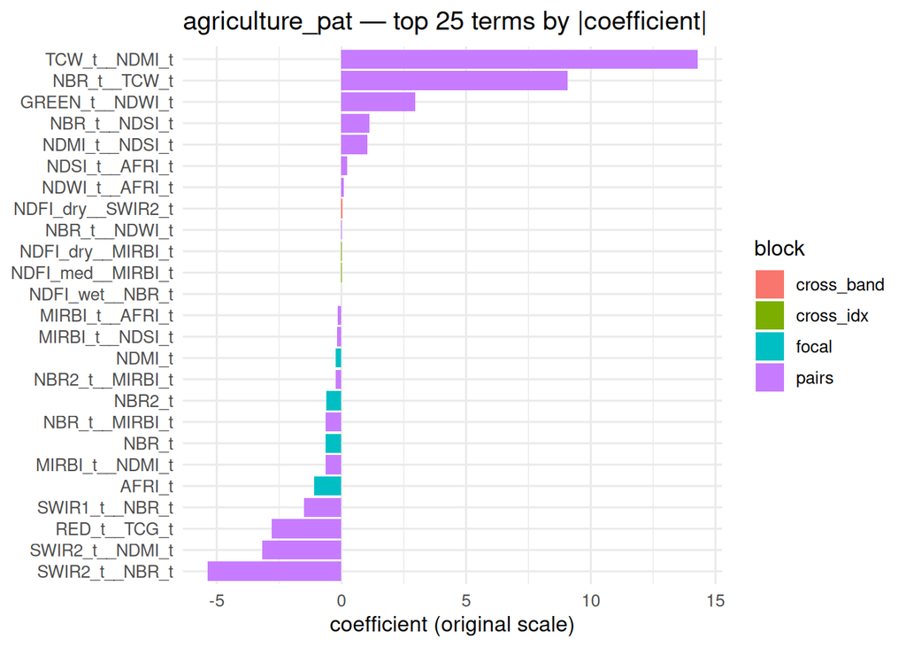

```r
coefs |>
  filter(block != "(intercept)", coefficient != 0) |>
  slice_max(abs(coefficient), n = 25) |>
  mutate(term = fct_reorder(term, coefficient)) |>
  ggplot(aes(coefficient, term, fill = block)) +
  geom_col() +
  labs(x = "coefficient (original scale)", y = NULL,
       title = sprintf("%s — top 25 terms by |coefficient|", cls))
```

## 1.4 Calibration (out-of-fold)

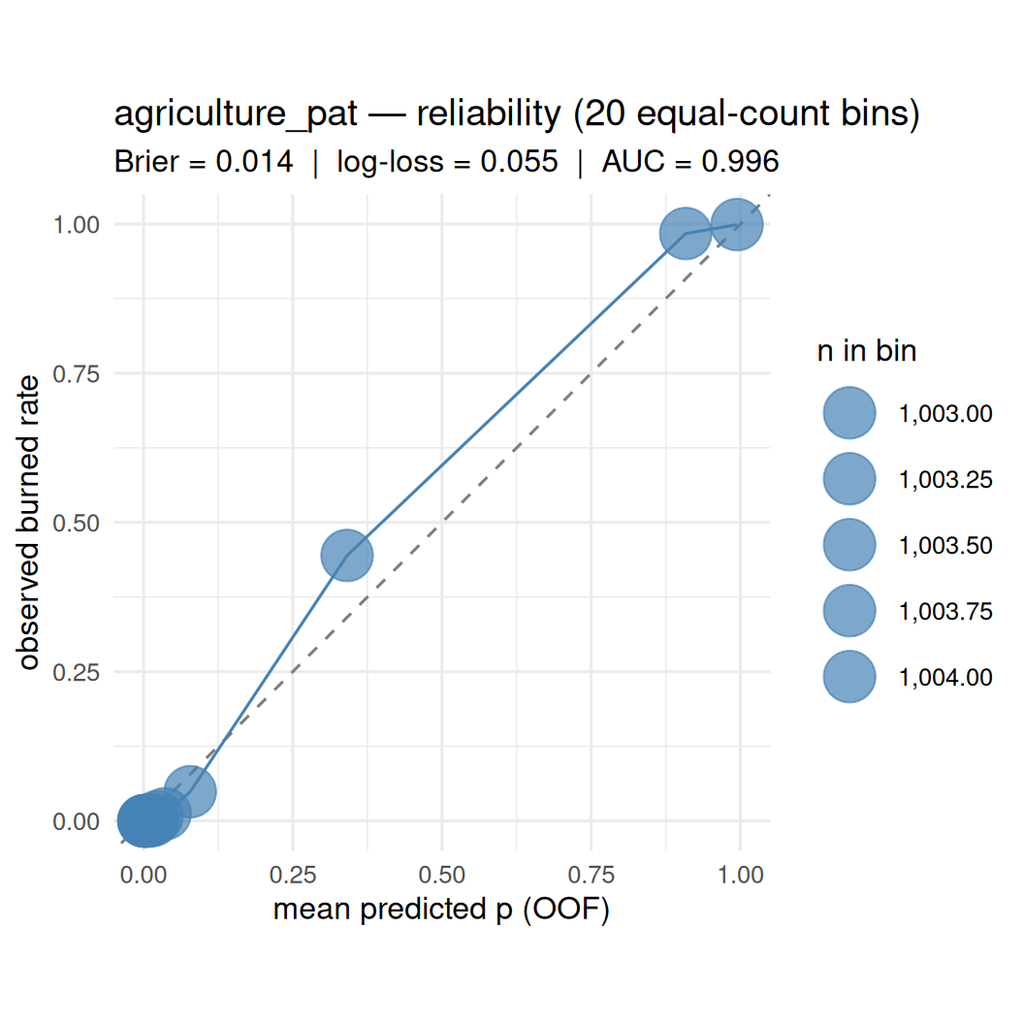

```r
n_bins <- 20
oof |>
  mutate(bin = ntile(p_oof, n_bins)) |>
  group_by(bin) |>
  summarise(mean_p = mean(p_oof), obs_rate = mean(burned), n = n(), .groups = "drop") |>
  ggplot(aes(mean_p, obs_rate)) +
  geom_abline(linetype = "dashed", color = "grey50") +
  geom_line(color = "steelblue") +
  geom_point(aes(size = n), color = "steelblue", alpha = 0.7) +
  scale_size_area(max_size = 9, labels = label_comma()) +
  coord_equal(xlim = c(0, 1), ylim = c(0, 1)) +
  labs(x = "mean predicted p (OOF)", y = "observed burned rate", size = "n in bin",
       title = sprintf("%s — reliability (%d equal-count bins)", cls, n_bins),
       subtitle = sprintf("Brier = %.3f  |  log-loss = %.3f  |  AUC = %.3f",
                          metrics$cv_brier[1], metrics$cv_logloss[1], metrics$cv_auc[1]))
```

## 1.5 Out-of-fold predicted-probability distribution

Distribution of OOF `p_i` split by the true label — shows where the model is confidently right vs confidently wrong. A good model pushes burned toward 1 and unburned toward 0. The histogram (per-label density) and the empirical CDF below use the same colour for each label.

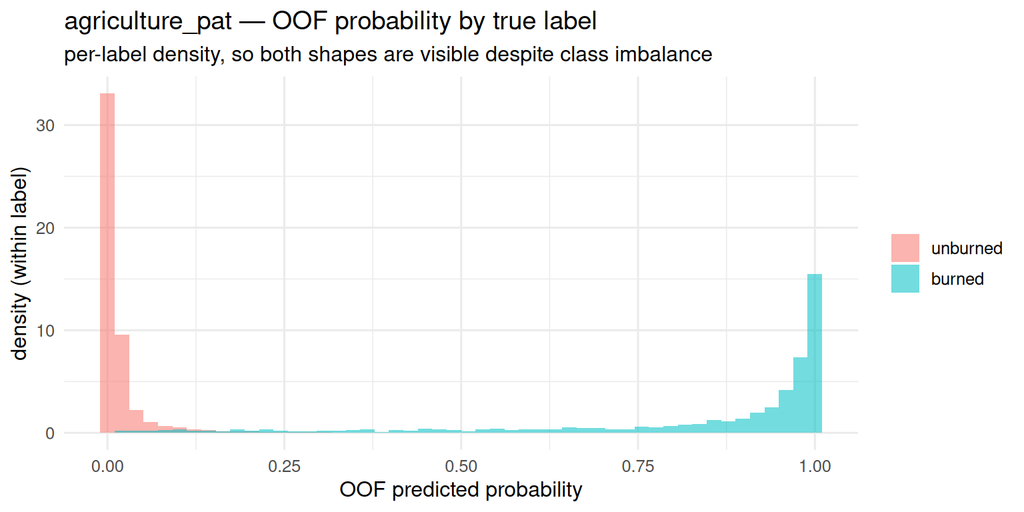

```r
oof |>
  mutate(label = factor(burned, 0:1, c("unburned", "burned"))) |>
  ggplot(aes(p_oof, after_stat(density), fill = label)) +
  geom_histogram(bins = 50, position = "identity", alpha = 0.55) +
  labs(x = "OOF predicted probability", y = "density (within label)", fill = NULL,
       title = sprintf("%s — OOF probability by true label", cls),
       subtitle = "per-label density, so both shapes are visible despite class imbalance")
```

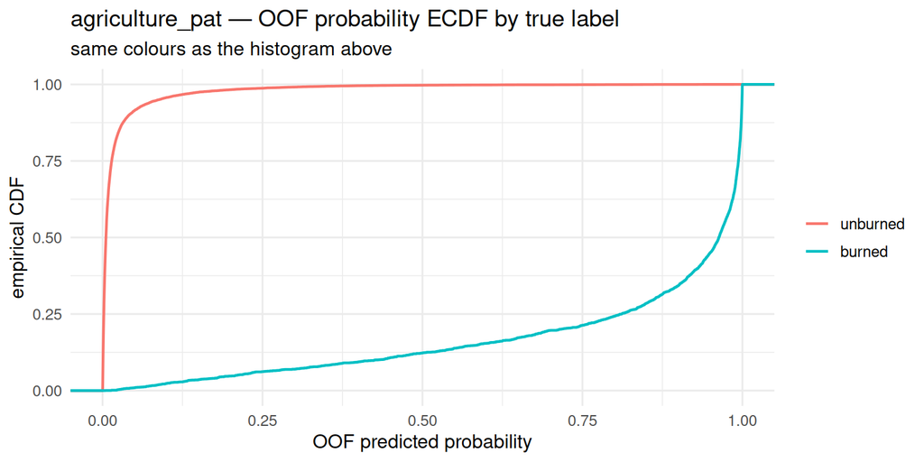

```r
oof |>
  mutate(label = factor(burned, 0:1, c("unburned", "burned"))) |>
  ggplot(aes(p_oof, color = label)) +
  stat_ecdf(geom = "step", linewidth = 0.8) +
  coord_cartesian(xlim = c(0, 1)) +
  labs(x = "OOF predicted probability", y = "empirical CDF", color = NULL,
       title = sprintf("%s — OOF probability ECDF by true label", cls),
       subtitle = "same colours as the histogram above")
```

## 1.6 Omission vs commission error

Threshold sweep over the OOF predictions: classify `p_oof ≥ τ` as burned, then plot, as a function of τ, the **omission error** (true burned that fall below τ — missed burns, `1 − recall`) and the **commission error** (predicted-burned that are actually unburned — false alarms, `1 − precision`). This is the curve for setting the two GEE thresholds: **seeds** want a high τ where commission is near zero; **candidates** want a lower τ that keeps omission acceptable. Computed entirely from the OOF predictions (no re-fit), so it is an honest, cross-validated estimate.

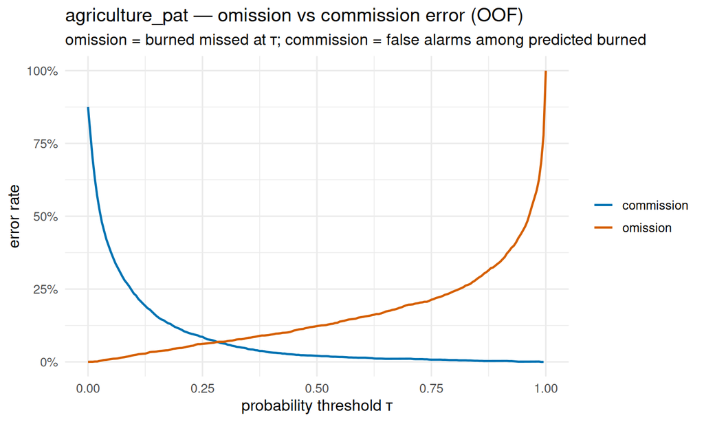

```r
pos <- oof$p_oof[oof$burned == 1]
neg <- oof$p_oof[oof$burned == 0]
P <- length(pos); N <- length(neg)
thr <- seq(0, 1, by = 0.005)
TP  <- P * (1 - ecdf(pos)(thr))            # true burned with p >= thr
FP  <- N * (1 - ecdf(neg)(thr))            # unburned with p >= thr (false alarms)
err <- tibble(
  thr        = thr,
  omission   = 1 - TP / P,                                   # missed burned
  commission = ifelse(TP + FP > 0, FP / (TP + FP), NA_real_) # false alarms among predicted burned
)
err |>
  pivot_longer(c(omission, commission), names_to = "error", values_to = "rate") |>
  ggplot(aes(thr, rate, color = error)) +
  geom_line(linewidth = 0.8, na.rm = TRUE) +
  scale_y_continuous(labels = label_percent()) +
  scale_color_manual(values = c(omission = "#D55E00", commission = "#0072B2")) +
  coord_cartesian(xlim = c(0, 1), ylim = c(0, 1)) +
  labs(x = "probability threshold τ", y = "error rate", color = NULL,
       title = sprintf("%s — omission vs commission error (OOF)", cls),
       subtitle = "omission = burned missed at τ; commission = false alarms among predicted burned")
```

## 1.7 By fire

OOF predictions per training fire, split by label — surfaces fires the model handles poorly (e.g. unburned points predicted high, or burned predicted low). Fires are keyed by `region_fire_id` (`region` + `fire_id`) so cross-region classes do not conflate fires that share a numeric id.

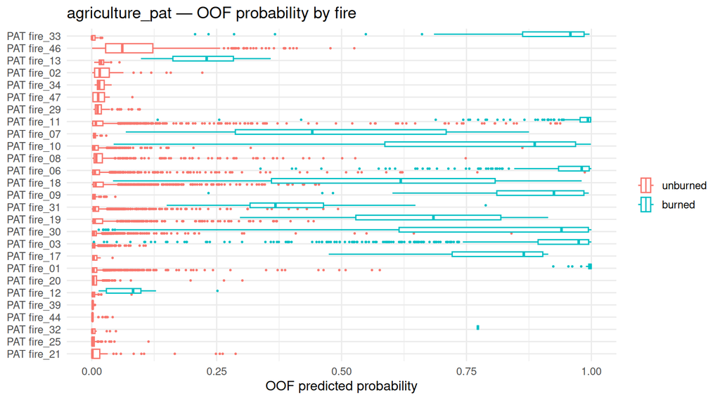

```r
oof |>
  mutate(label = factor(burned, 0:1, c("unburned", "burned")),
         region_fire_id = fct_reorder(paste(region, fire_id), p_oof, .fun = median)) |>
  ggplot(aes(p_oof, region_fire_id, color = label)) +
  geom_boxplot(outlier.size = 0.4, position = position_dodge(width = 0.6)) +
  labs(x = "OOF predicted probability", y = NULL, color = NULL,
       title = sprintf("%s — OOF probability by fire", cls))
```

```r
oof |>
  mutate(region_fire_id = paste(region, fire_id)) |>
  group_by(region_fire_id) |>
  summarise(n = n(), n_burned = sum(burned),
            mean_p_unburned = mean(p_oof[burned == 0]),
            mean_p_burned   = mean(p_oof[burned == 1]), .groups = "drop") |>
  arrange(desc(n)) |>
  mutate(across(starts_with("mean_p"), \(x) round(x, 3))) |>
  kable()
```

| region_fire_id | n | n_burned | mean_p_unburned | mean_p_burned |
| --- | --- | --- | --- | --- |
| PAT fire_03 | 3235 | 909 | 0.005 | 0.900 |
| PAT fire_30 | 3157 | 507 | 0.010 | 0.778 |
| PAT fire_31 | 2125 | 23 | 0.015 | 0.395 |
| PAT fire_01 | 1833 | 44 | 0.014 | 0.993 |
| PAT fire_06 | 1805 | 283 | 0.020 | 0.937 |
| PAT fire_18 | 1729 | 90 | 0.027 | 0.563 |
| PAT fire_11 | 1719 | 224 | 0.037 | 0.966 |
| PAT fire_10 | 1303 | 286 | 0.012 | 0.750 |
| PAT fire_19 | 796 | 10 | 0.029 | 0.666 |
| PAT fire_46 | 780 | 0 | 0.086 | NaN |
| PAT fire_08 | 414 | 0 | 0.040 | NaN |
| PAT fire_20 | 289 | 0 | 0.010 | NaN |
| PAT fire_25 | 123 | 0 | 0.006 | NaN |
| PAT fire_09 | 116 | 34 | 0.006 | 0.854 |
| PAT fire_12 | 115 | 13 | 0.004 | 0.078 |
| PAT fire_29 | 82 | 0 | 0.021 | NaN |
| PAT fire_07 | 66 | 26 | 0.007 | 0.474 |
| PAT fire_33 | 63 | 41 | 0.005 | 0.859 |
| PAT fire_21 | 60 | 0 | 0.031 | NaN |
| PAT fire_17 | 55 | 7 | 0.006 | 0.786 |
| PAT fire_02 | 54 | 0 | 0.032 | NaN |
| PAT fire_44 | 46 | 0 | 0.007 | NaN |
| PAT fire_13 | 32 | 8 | 0.021 | 0.227 |
| PAT fire_39 | 28 | 0 | 0.002 | NaN |
| PAT fire_32 | 19 | 1 | 0.008 | 0.773 |
| PAT fire_47 | 14 | 0 | 0.018 | NaN |
| PAT fire_34 | 11 | 0 | 0.019 | NaN |

# 2 forest_pat

veg_fire code **9** · regions PAT · 246,885 obs · 42,824 positives (17.3%) · K = 10 · 72 nonzero terms

## 2.1 Summary

```r
metrics |>
  mutate(across(where(is.numeric), \(x) signif(x, 4))) |>
  pivot_longer(everything(), names_to = "metric", values_to = "value",
               values_transform = as.character) |>
  kable()
```

| metric | value |
| --- | --- |
| veg_fire | 9 |
| veg_fire_name | forest_pat |
| regions | PAT |
| n_obs | 246900 |
| n_pos | 42820 |
| K | 10 |
| n_terms | 427 |
| alpha | 0.25 |
| lambda_rule | 1se |
| lambda | 0.03434 |
| lambda_min | 0.002107 |
| lambda_1se | 0.03434 |
| cv_deviance | 0.2316 |
| cv_logloss | 0.1159 |
| cv_brier | 0.02989 |
| cv_auc | NA |
| n_nonzero | 72 |

The model is fit with elastic net; `alpha` and `lambda` are tuned by grouped (leave-several-fires-out) K-fold CV. `lambda` reported is the one selected by `lambda_rule`. `n_nonzero` is the count of nonzero coefficients (excl. intercept).

## 2.2 Elastic-net tuning

CV binomial deviance along the lambda path, one curve per `alpha`. Vertical lines mark `lambda.min` (dashed) and `lambda.1se` (dotted) of the selected alpha; the chosen model sits at the rule in `metrics$lambda_rule`.

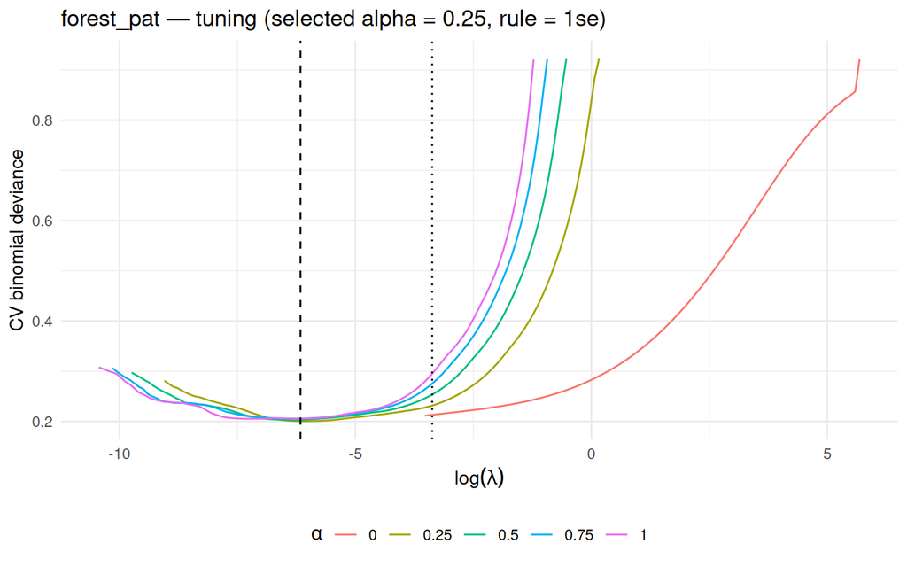

```r
sel_alpha <- metrics$alpha[1]
ggplot(tuning, aes(log(lambda), cvm, color = factor(alpha))) +
  geom_line() +
  geom_vline(xintercept = log(metrics$lambda_min[1]), linetype = "dashed") +
  geom_vline(xintercept = log(metrics$lambda_1se[1]), linetype = "dotted") +
  labs(x = expression(log(lambda)), y = "CV binomial deviance",
       color = expression(alpha),
       title = sprintf("%s — tuning (selected alpha = %.2f, rule = %s)",
                       cls, sel_alpha, metrics$lambda_rule[1])) +
  theme(legend.position = "bottom")
```

## 2.3 Coefficients

Nonzero coefficients by block (the GEE predictor blocks) and the strongest terms.

Coefficients are on the **original feature scale** — `glmnet` standardizes each predictor internally (`standardize = TRUE`) but back-transforms the returned coefficients to the raw scale. A clean cross-term comparison would need them on the *standardized* scale (multiply each $\beta_j$ by $\mathrm{sd}(x_j)$, i.e. the effect of a 1-SD change), but the per-feature SDs are not exported by `02-model_fitting.R` and recovering them would mean rebuilding the full 427-column design matrix from the region tables here. That is deliberately left out — read the magnitudes below as raw-scale, so a large coefficient on a small-variance term need not mean a large effect.

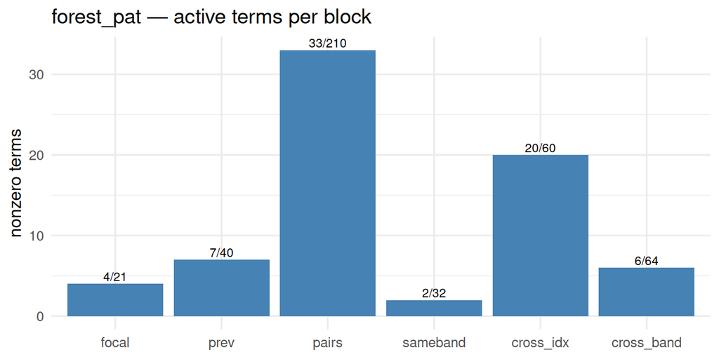

```r
coefs |>
  filter(block != "(intercept)") |>
  group_by(block) |>
  summarise(n_terms = n(), n_nonzero = sum(coefficient != 0), .groups = "drop") |>
  mutate(block = factor(block, block_lvls)) |>
  ggplot(aes(block, n_nonzero)) +
  geom_col(fill = "steelblue") +
  geom_text(aes(label = sprintf("%d/%d", n_nonzero, n_terms)), vjust = -0.3, size = 3) +
  labs(x = NULL, y = "nonzero terms", title = sprintf("%s — active terms per block", cls))
```

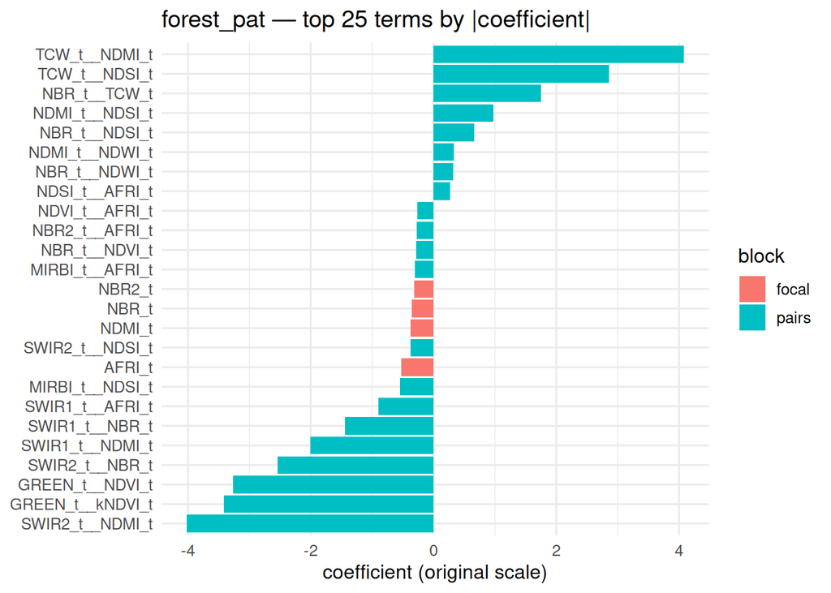

```r
coefs |>
  filter(block != "(intercept)", coefficient != 0) |>
  slice_max(abs(coefficient), n = 25) |>
  mutate(term = fct_reorder(term, coefficient)) |>
  ggplot(aes(coefficient, term, fill = block)) +
  geom_col() +
  labs(x = "coefficient (original scale)", y = NULL,
       title = sprintf("%s — top 25 terms by |coefficient|", cls))
```

## 2.4 Calibration (out-of-fold)

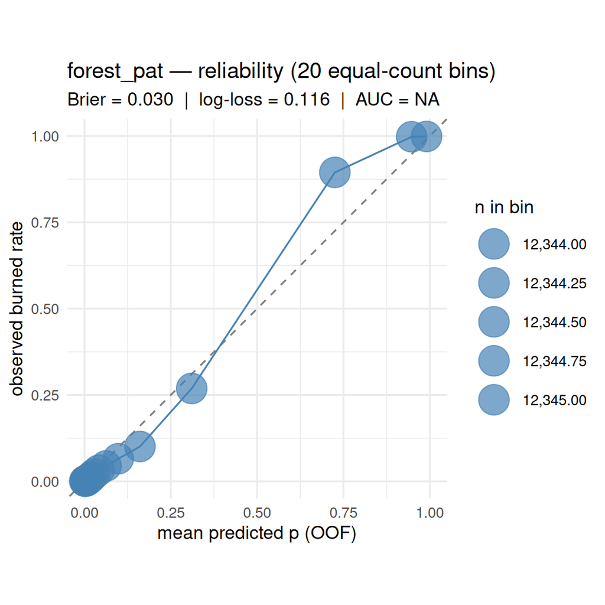

```r
n_bins <- 20
oof |>
  mutate(bin = ntile(p_oof, n_bins)) |>
  group_by(bin) |>
  summarise(mean_p = mean(p_oof), obs_rate = mean(burned), n = n(), .groups = "drop") |>
  ggplot(aes(mean_p, obs_rate)) +
  geom_abline(linetype = "dashed", color = "grey50") +
  geom_line(color = "steelblue") +
  geom_point(aes(size = n), color = "steelblue", alpha = 0.7) +
  scale_size_area(max_size = 9, labels = label_comma()) +
  coord_equal(xlim = c(0, 1), ylim = c(0, 1)) +
  labs(x = "mean predicted p (OOF)", y = "observed burned rate", size = "n in bin",
       title = sprintf("%s — reliability (%d equal-count bins)", cls, n_bins),
       subtitle = sprintf("Brier = %.3f  |  log-loss = %.3f  |  AUC = %.3f",
                          metrics$cv_brier[1], metrics$cv_logloss[1], metrics$cv_auc[1]))
```

## 2.5 Out-of-fold predicted-probability distribution

Distribution of OOF `p_i` split by the true label — shows where the model is confidently right vs confidently wrong. A good model pushes burned toward 1 and unburned toward 0. The histogram (per-label density) and the empirical CDF below use the same colour for each label.

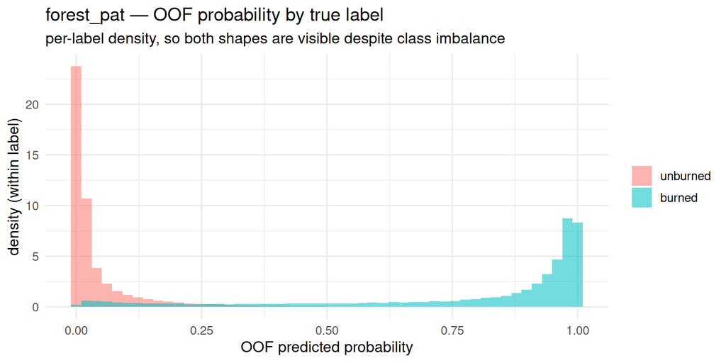

```r
oof |>
  mutate(label = factor(burned, 0:1, c("unburned", "burned"))) |>
  ggplot(aes(p_oof, after_stat(density), fill = label)) +
  geom_histogram(bins = 50, position = "identity", alpha = 0.55) +
  labs(x = "OOF predicted probability", y = "density (within label)", fill = NULL,
       title = sprintf("%s — OOF probability by true label", cls),
       subtitle = "per-label density, so both shapes are visible despite class imbalance")
```

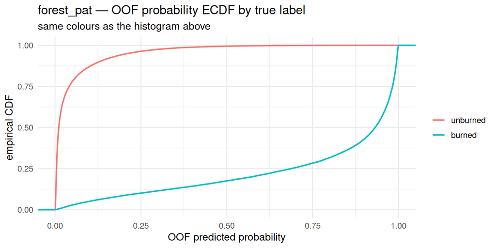

```r
oof |>
  mutate(label = factor(burned, 0:1, c("unburned", "burned"))) |>
  ggplot(aes(p_oof, color = label)) +
  stat_ecdf(geom = "step", linewidth = 0.8) +
  coord_cartesian(xlim = c(0, 1)) +
  labs(x = "OOF predicted probability", y = "empirical CDF", color = NULL,
       title = sprintf("%s — OOF probability ECDF by true label", cls),
       subtitle = "same colours as the histogram above")
```

## 2.6 Omission vs commission error

Threshold sweep over the OOF predictions: classify `p_oof ≥ τ` as burned, then plot, as a function of τ, the **omission error** (true burned that fall below τ — missed burns, `1 − recall`) and the **commission error** (predicted-burned that are actually unburned — false alarms, `1 − precision`). This is the curve for setting the two GEE thresholds: **seeds** want a high τ where commission is near zero; **candidates** want a lower τ that keeps omission acceptable. Computed entirely from the OOF predictions (no re-fit), so it is an honest, cross-validated estimate.

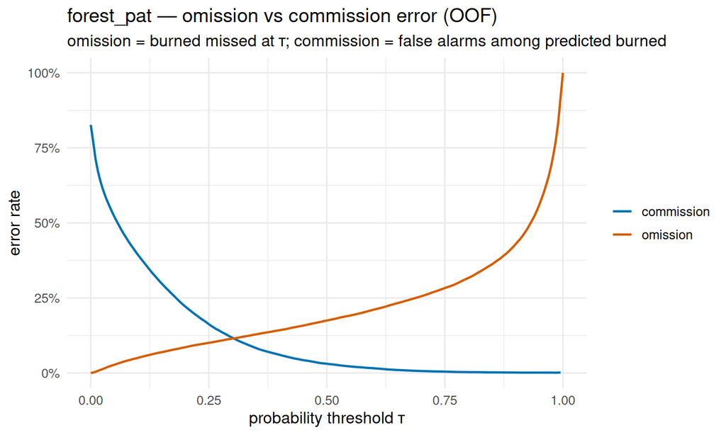

```r
pos <- oof$p_oof[oof$burned == 1]
neg <- oof$p_oof[oof$burned == 0]
P <- length(pos); N <- length(neg)
thr <- seq(0, 1, by = 0.005)
TP  <- P * (1 - ecdf(pos)(thr))            # true burned with p >= thr
FP  <- N * (1 - ecdf(neg)(thr))            # unburned with p >= thr (false alarms)
err <- tibble(
  thr        = thr,
  omission   = 1 - TP / P,                                   # missed burned
  commission = ifelse(TP + FP > 0, FP / (TP + FP), NA_real_) # false alarms among predicted burned
)
err |>
  pivot_longer(c(omission, commission), names_to = "error", values_to = "rate") |>
  ggplot(aes(thr, rate, color = error)) +
  geom_line(linewidth = 0.8, na.rm = TRUE) +
  scale_y_continuous(labels = label_percent()) +
  scale_color_manual(values = c(omission = "#D55E00", commission = "#0072B2")) +
  coord_cartesian(xlim = c(0, 1), ylim = c(0, 1)) +
  labs(x = "probability threshold τ", y = "error rate", color = NULL,
       title = sprintf("%s — omission vs commission error (OOF)", cls),
       subtitle = "omission = burned missed at τ; commission = false alarms among predicted burned")
```

## 2.7 By fire

OOF predictions per training fire, split by label — surfaces fires the model handles poorly (e.g. unburned points predicted high, or burned predicted low). Fires are keyed by `region_fire_id` (`region` + `fire_id`) so cross-region classes do not conflate fires that share a numeric id.

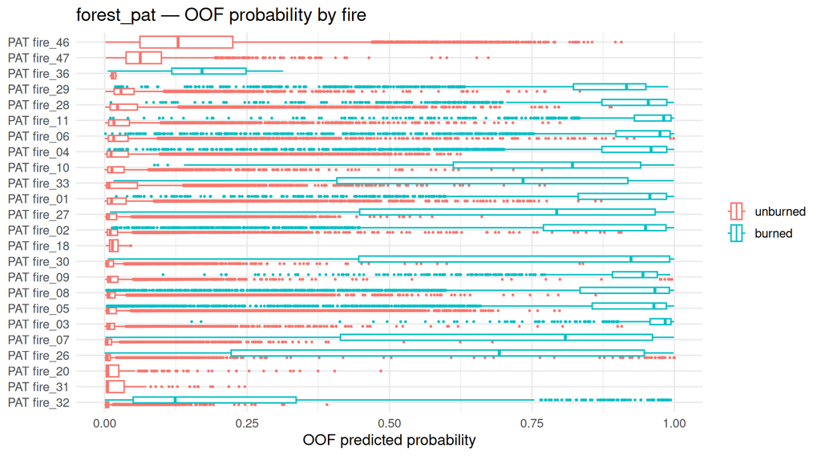

```r
oof |>
  mutate(label = factor(burned, 0:1, c("unburned", "burned")),
         region_fire_id = fct_reorder(paste(region, fire_id), p_oof, .fun = median)) |>
  ggplot(aes(p_oof, region_fire_id, color = label)) +
  geom_boxplot(outlier.size = 0.4, position = position_dodge(width = 0.6)) +
  labs(x = "OOF predicted probability", y = NULL, color = NULL,
       title = sprintf("%s — OOF probability by fire", cls))
```

```r
oof |>
  mutate(region_fire_id = paste(region, fire_id)) |>
  group_by(region_fire_id) |>
  summarise(n = n(), n_burned = sum(burned),
            mean_p_unburned = mean(p_oof[burned == 0]),
            mean_p_burned   = mean(p_oof[burned == 1]), .groups = "drop") |>
  arrange(desc(n)) |>
  mutate(across(starts_with("mean_p"), \(x) round(x, 3))) |>
  kable()
```

| region_fire_id | n | n_burned | mean_p_unburned | mean_p_burned |
| --- | --- | --- | --- | --- |
| PAT fire_05 | 23408 | 4651 | 0.040 | 0.829 |
| PAT fire_08 | 20007 | 3937 | 0.031 | 0.852 |
| PAT fire_46 | 16451 | 0 | 0.161 | NaN |
| PAT fire_02 | 16342 | 3166 | 0.025 | 0.830 |
| PAT fire_07 | 15189 | 2561 | 0.014 | 0.668 |
| PAT fire_04 | 14913 | 3626 | 0.046 | 0.886 |
| PAT fire_01 | 14550 | 1855 | 0.042 | 0.866 |
| PAT fire_33 | 14259 | 2885 | 0.042 | 0.652 |
| PAT fire_27 | 13570 | 3875 | 0.031 | 0.685 |
| PAT fire_28 | 12863 | 1961 | 0.054 | 0.895 |
| PAT fire_29 | 12451 | 2266 | 0.044 | 0.839 |
| PAT fire_06 | 12225 | 2411 | 0.043 | 0.884 |
| PAT fire_30 | 10390 | 3051 | 0.019 | 0.716 |
| PAT fire_03 | 10370 | 644 | 0.020 | 0.956 |
| PAT fire_26 | 9552 | 1655 | 0.018 | 0.592 |
| PAT fire_32 | 8017 | 989 | 0.010 | 0.241 |
| PAT fire_09 | 7302 | 929 | 0.026 | 0.890 |
| PAT fire_11 | 7139 | 1472 | 0.047 | 0.930 |
| PAT fire_10 | 5225 | 879 | 0.034 | 0.752 |
| PAT fire_47 | 2263 | 0 | 0.078 | NaN |
| PAT fire_20 | 244 | 0 | 0.036 | NaN |
| PAT fire_31 | 71 | 0 | 0.040 | NaN |
| PAT fire_18 | 64 | 0 | 0.016 | NaN |
| PAT fire_36 | 20 | 11 | 0.015 | 0.174 |

# 3 shrubland_pat

veg_fire code **22** · regions PAT · 190,101 obs · 42,320 positives (22.3%) · K = 10 · 28 nonzero terms

## 3.1 Summary

```r
metrics |>
  mutate(across(where(is.numeric), \(x) signif(x, 4))) |>
  pivot_longer(everything(), names_to = "metric", values_to = "value",
               values_transform = as.character) |>
  kable()
```

| metric | value |
| --- | --- |
| veg_fire | 22 |
| veg_fire_name | shrubland_pat |
| regions | PAT |
| n_obs | 190100 |
| n_pos | 42320 |
| K | 10 |
| n_terms | 427 |
| alpha | 0.75 |
| lambda_rule | 1se |
| lambda | 0.01439 |
| lambda_min | 0.000883 |
| lambda_1se | 0.01439 |
| cv_deviance | 0.3192 |
| cv_logloss | 0.1599 |
| cv_brier | 0.0427 |
| cv_auc | NA |
| n_nonzero | 28 |

The model is fit with elastic net; `alpha` and `lambda` are tuned by grouped (leave-several-fires-out) K-fold CV. `lambda` reported is the one selected by `lambda_rule`. `n_nonzero` is the count of nonzero coefficients (excl. intercept).

## 3.2 Elastic-net tuning

CV binomial deviance along the lambda path, one curve per `alpha`. Vertical lines mark `lambda.min` (dashed) and `lambda.1se` (dotted) of the selected alpha; the chosen model sits at the rule in `metrics$lambda_rule`.

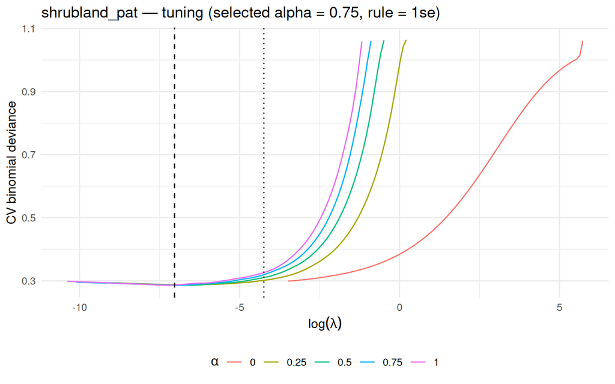

```r
sel_alpha <- metrics$alpha[1]
ggplot(tuning, aes(log(lambda), cvm, color = factor(alpha))) +
  geom_line() +
  geom_vline(xintercept = log(metrics$lambda_min[1]), linetype = "dashed") +
  geom_vline(xintercept = log(metrics$lambda_1se[1]), linetype = "dotted") +
  labs(x = expression(log(lambda)), y = "CV binomial deviance",
       color = expression(alpha),
       title = sprintf("%s — tuning (selected alpha = %.2f, rule = %s)",
                       cls, sel_alpha, metrics$lambda_rule[1])) +
  theme(legend.position = "bottom")
```

## 3.3 Coefficients

Nonzero coefficients by block (the GEE predictor blocks) and the strongest terms.

Coefficients are on the **original feature scale** — `glmnet` standardizes each predictor internally (`standardize = TRUE`) but back-transforms the returned coefficients to the raw scale. A clean cross-term comparison would need them on the *standardized* scale (multiply each $\beta_j$ by $\mathrm{sd}(x_j)$, i.e. the effect of a 1-SD change), but the per-feature SDs are not exported by `02-model_fitting.R` and recovering them would mean rebuilding the full 427-column design matrix from the region tables here. That is deliberately left out — read the magnitudes below as raw-scale, so a large coefficient on a small-variance term need not mean a large effect.

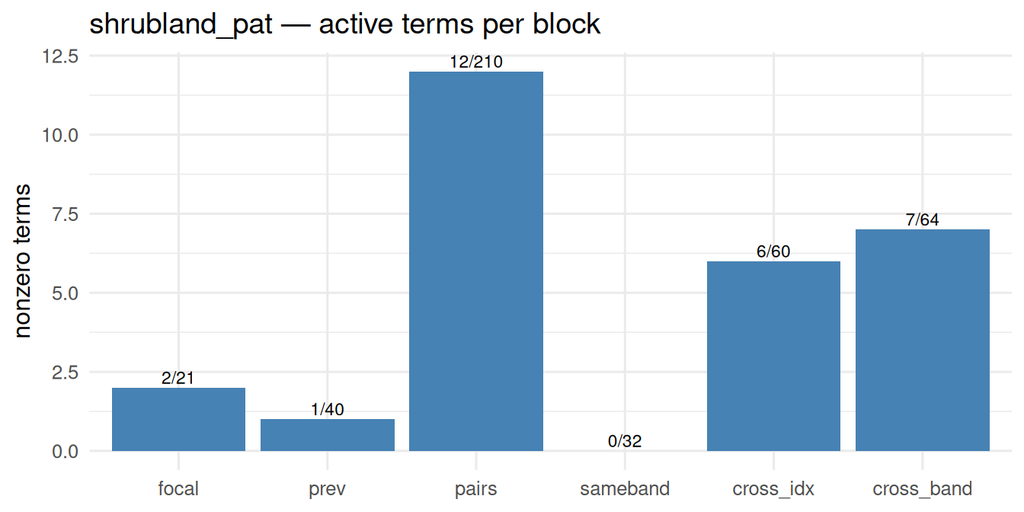

```r
coefs |>
  filter(block != "(intercept)") |>
  group_by(block) |>
  summarise(n_terms = n(), n_nonzero = sum(coefficient != 0), .groups = "drop") |>
  mutate(block = factor(block, block_lvls)) |>
  ggplot(aes(block, n_nonzero)) +
  geom_col(fill = "steelblue") +
  geom_text(aes(label = sprintf("%d/%d", n_nonzero, n_terms)), vjust = -0.3, size = 3) +
  labs(x = NULL, y = "nonzero terms", title = sprintf("%s — active terms per block", cls))
```

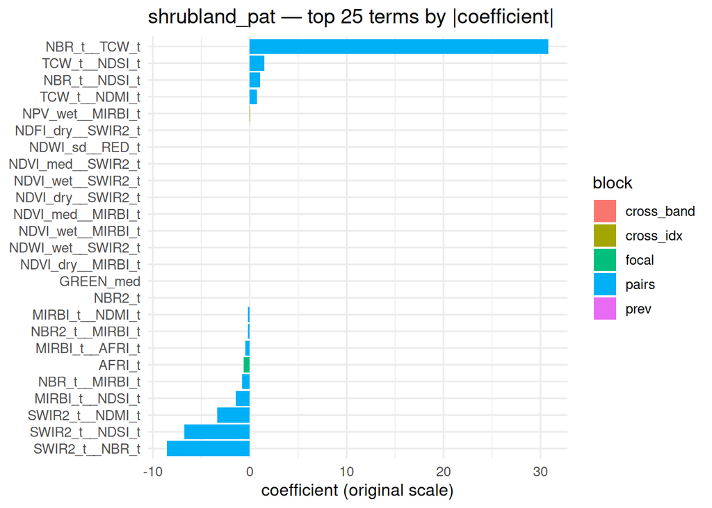

```r
coefs |>
  filter(block != "(intercept)", coefficient != 0) |>
  slice_max(abs(coefficient), n = 25) |>
  mutate(term = fct_reorder(term, coefficient)) |>
  ggplot(aes(coefficient, term, fill = block)) +
  geom_col() +
  labs(x = "coefficient (original scale)", y = NULL,
       title = sprintf("%s — top 25 terms by |coefficient|", cls))
```

## 3.4 Calibration (out-of-fold)

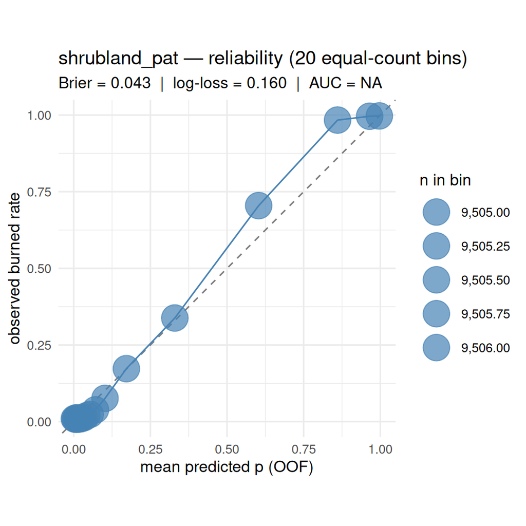

```r
n_bins <- 20
oof |>
  mutate(bin = ntile(p_oof, n_bins)) |>
  group_by(bin) |>
  summarise(mean_p = mean(p_oof), obs_rate = mean(burned), n = n(), .groups = "drop") |>
  ggplot(aes(mean_p, obs_rate)) +
  geom_abline(linetype = "dashed", color = "grey50") +
  geom_line(color = "steelblue") +
  geom_point(aes(size = n), color = "steelblue", alpha = 0.7) +
  scale_size_area(max_size = 9, labels = label_comma()) +
  coord_equal(xlim = c(0, 1), ylim = c(0, 1)) +
  labs(x = "mean predicted p (OOF)", y = "observed burned rate", size = "n in bin",
       title = sprintf("%s — reliability (%d equal-count bins)", cls, n_bins),
       subtitle = sprintf("Brier = %.3f  |  log-loss = %.3f  |  AUC = %.3f",
                          metrics$cv_brier[1], metrics$cv_logloss[1], metrics$cv_auc[1]))
```

## 3.5 Out-of-fold predicted-probability distribution

Distribution of OOF `p_i` split by the true label — shows where the model is confidently right vs confidently wrong. A good model pushes burned toward 1 and unburned toward 0. The histogram (per-label density) and the empirical CDF below use the same colour for each label.

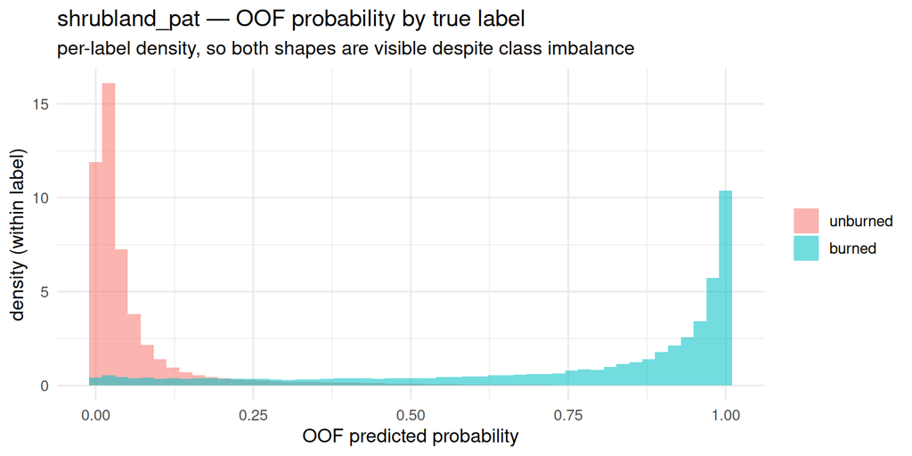

```r
oof |>
  mutate(label = factor(burned, 0:1, c("unburned", "burned"))) |>
  ggplot(aes(p_oof, after_stat(density), fill = label)) +
  geom_histogram(bins = 50, position = "identity", alpha = 0.55) +
  labs(x = "OOF predicted probability", y = "density (within label)", fill = NULL,
       title = sprintf("%s — OOF probability by true label", cls),
       subtitle = "per-label density, so both shapes are visible despite class imbalance")
```

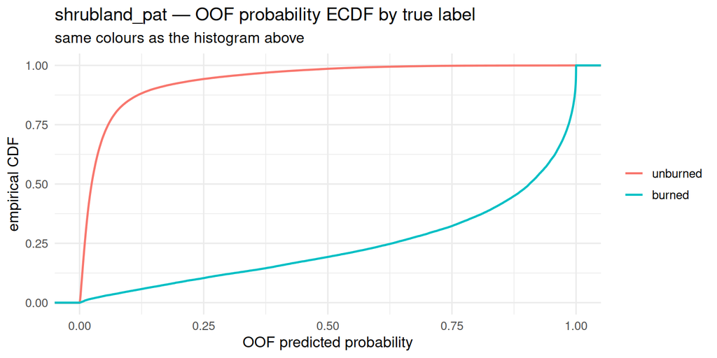

```r
oof |>
  mutate(label = factor(burned, 0:1, c("unburned", "burned"))) |>
  ggplot(aes(p_oof, color = label)) +
  stat_ecdf(geom = "step", linewidth = 0.8) +
  coord_cartesian(xlim = c(0, 1)) +
  labs(x = "OOF predicted probability", y = "empirical CDF", color = NULL,
       title = sprintf("%s — OOF probability ECDF by true label", cls),
       subtitle = "same colours as the histogram above")
```

## 3.6 Omission vs commission error

Threshold sweep over the OOF predictions: classify `p_oof ≥ τ` as burned, then plot, as a function of τ, the **omission error** (true burned that fall below τ — missed burns, `1 − recall`) and the **commission error** (predicted-burned that are actually unburned — false alarms, `1 − precision`). This is the curve for setting the two GEE thresholds: **seeds** want a high τ where commission is near zero; **candidates** want a lower τ that keeps omission acceptable. Computed entirely from the OOF predictions (no re-fit), so it is an honest, cross-validated estimate.

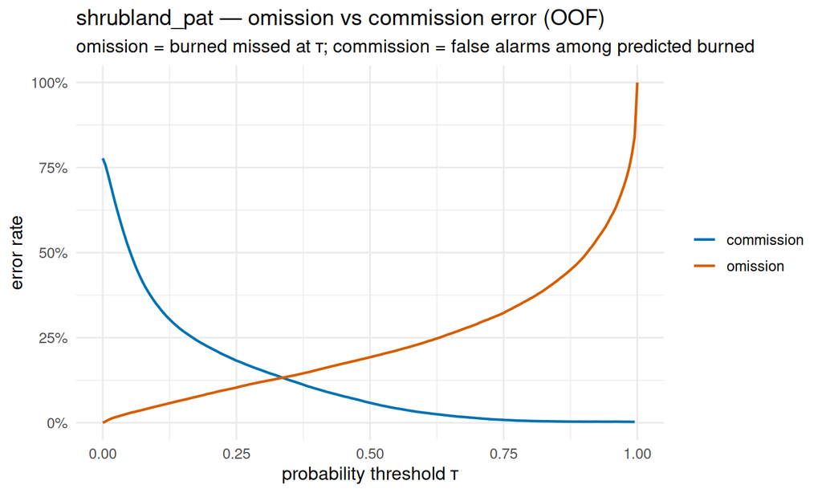

```r
pos <- oof$p_oof[oof$burned == 1]
neg <- oof$p_oof[oof$burned == 0]
P <- length(pos); N <- length(neg)
thr <- seq(0, 1, by = 0.005)
TP  <- P * (1 - ecdf(pos)(thr))            # true burned with p >= thr
FP  <- N * (1 - ecdf(neg)(thr))            # unburned with p >= thr (false alarms)
err <- tibble(
  thr        = thr,
  omission   = 1 - TP / P,                                   # missed burned
  commission = ifelse(TP + FP > 0, FP / (TP + FP), NA_real_) # false alarms among predicted burned
)
err |>
  pivot_longer(c(omission, commission), names_to = "error", values_to = "rate") |>
  ggplot(aes(thr, rate, color = error)) +
  geom_line(linewidth = 0.8, na.rm = TRUE) +
  scale_y_continuous(labels = label_percent()) +
  scale_color_manual(values = c(omission = "#D55E00", commission = "#0072B2")) +
  coord_cartesian(xlim = c(0, 1), ylim = c(0, 1)) +
  labs(x = "probability threshold τ", y = "error rate", color = NULL,
       title = sprintf("%s — omission vs commission error (OOF)", cls),
       subtitle = "omission = burned missed at τ; commission = false alarms among predicted burned")
```

## 3.7 By fire

OOF predictions per training fire, split by label — surfaces fires the model handles poorly (e.g. unburned points predicted high, or burned predicted low). Fires are keyed by `region_fire_id` (`region` + `fire_id`) so cross-region classes do not conflate fires that share a numeric id.

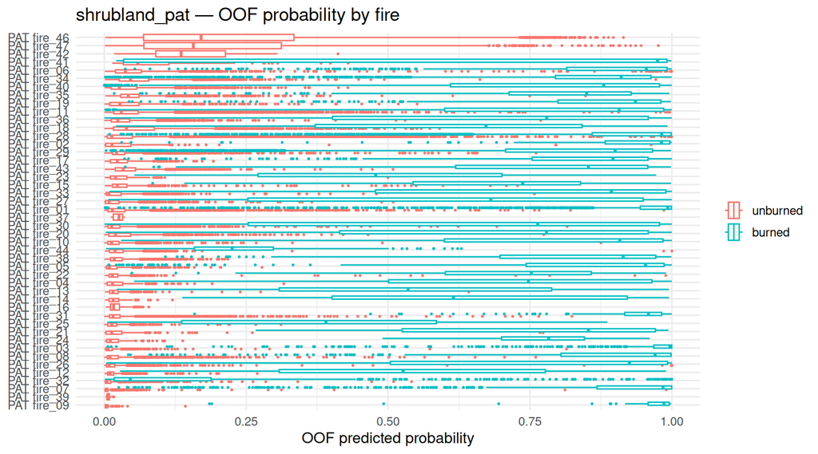

```r
oof |>
  mutate(label = factor(burned, 0:1, c("unburned", "burned")),
         region_fire_id = fct_reorder(paste(region, fire_id), p_oof, .fun = median)) |>
  ggplot(aes(p_oof, region_fire_id, color = label)) +
  geom_boxplot(outlier.size = 0.4, position = position_dodge(width = 0.6)) +
  labs(x = "OOF predicted probability", y = NULL, color = NULL,
       title = sprintf("%s — OOF probability by fire", cls))
```

```r
oof |>
  mutate(region_fire_id = paste(region, fire_id)) |>
  group_by(region_fire_id) |>
  summarise(n = n(), n_burned = sum(burned),
            mean_p_unburned = mean(p_oof[burned == 0]),
            mean_p_burned   = mean(p_oof[burned == 1]), .groups = "drop") |>
  arrange(desc(n)) |>
  mutate(across(starts_with("mean_p"), \(x) round(x, 3))) |>
  kable()
```

| region_fire_id | n | n_burned | mean_p_unburned | mean_p_burned |
| --- | --- | --- | --- | --- |
| PAT fire_29 | 19585 | 7321 | 0.032 | 0.799 |
| PAT fire_46 | 16451 | 0 | 0.220 | NaN |
| PAT fire_28 | 15998 | 5147 | 0.057 | 0.892 |
| PAT fire_34 | 12267 | 2586 | 0.058 | 0.822 |
| PAT fire_11 | 12240 | 3286 | 0.057 | 0.763 |
| PAT fire_01 | 10613 | 2662 | 0.034 | 0.914 |
| PAT fire_36 | 10269 | 3714 | 0.034 | 0.668 |
| PAT fire_30 | 9830 | 3243 | 0.023 | 0.630 |
| PAT fire_31 | 8121 | 203 | 0.026 | 0.924 |
| PAT fire_43 | 6532 | 138 | 0.042 | 0.755 |
| PAT fire_18 | 4922 | 394 | 0.066 | 0.602 |
| PAT fire_35 | 4748 | 705 | 0.053 | 0.793 |
| PAT fire_40 | 4272 | 1506 | 0.044 | 0.734 |
| PAT fire_44 | 3763 | 423 | 0.025 | 0.236 |
| PAT fire_26 | 3632 | 678 | 0.018 | 0.741 |
| PAT fire_06 | 3476 | 1065 | 0.065 | 0.871 |
| PAT fire_38 | 3426 | 333 | 0.026 | 0.808 |
| PAT fire_32 | 3420 | 784 | 0.012 | 0.178 |
| PAT fire_07 | 3198 | 1128 | 0.008 | 0.870 |
| PAT fire_12 | 2949 | 401 | 0.014 | 0.536 |
| PAT fire_08 | 2752 | 441 | 0.029 | 0.849 |
| PAT fire_19 | 2729 | 670 | 0.044 | 0.851 |
| PAT fire_03 | 2384 | 762 | 0.013 | 0.931 |
| PAT fire_33 | 2378 | 791 | 0.024 | 0.726 |
| PAT fire_47 | 2263 | 0 | 0.215 | NaN |
| PAT fire_10 | 2225 | 694 | 0.023 | 0.760 |
| PAT fire_20 | 2104 | 232 | 0.037 | 0.673 |
| PAT fire_22 | 1961 | 413 | 0.022 | 0.715 |
| PAT fire_15 | 1825 | 368 | 0.038 | 0.689 |
| PAT fire_17 | 1751 | 552 | 0.029 | 0.816 |
| PAT fire_27 | 1743 | 616 | 0.026 | 0.599 |
| PAT fire_13 | 1444 | 226 | 0.020 | 0.538 |
| PAT fire_25 | 1263 | 112 | 0.018 | 0.387 |
| PAT fire_05 | 1080 | 331 | 0.019 | 0.780 |
| PAT fire_23 | 437 | 120 | 0.029 | 0.483 |
| PAT fire_02 | 359 | 115 | 0.041 | 0.874 |
| PAT fire_16 | 346 | 0 | 0.020 | NaN |
| PAT fire_04 | 290 | 43 | 0.027 | 0.694 |
| PAT fire_21 | 283 | 8 | 0.030 | 0.729 |
| PAT fire_09 | 263 | 55 | 0.006 | 0.933 |
| PAT fire_14 | 194 | 14 | 0.020 | 0.619 |
| PAT fire_41 | 130 | 24 | 0.095 | 0.661 |
| PAT fire_24 | 129 | 16 | 0.022 | 0.775 |
| PAT fire_42 | 33 | 0 | 0.156 | NaN |
| PAT fire_39 | 13 | 0 | 0.008 | NaN |
| PAT fire_37 | 10 | 0 | 0.025 | NaN |